# lab-notebook

```r
library(finitefourierfits)
set.seed(42)
```

# 2020 July 13-15

I developed the basic algorithm ideas over these days. The goal is to take a bivariate relation that seems to be functional and fit a partial Fourier basis to it. Fewer terms will mean less computational complexity and more smoothness.

The steps that I came up with are

1. pad the response variable with zeros so that its length is more than doubled and a power of two.
2. find a mapping, `u(x)`, from the causal variable to angular frequency.
3. compute the DFT of the padded variable with `fft`
4. use `Mod` to compute `a`, the amplitudes of each term in the DFT.
5. use `Arg` to compute `p`, the phases of each term in the DFT.
6. choose a limited number of terms to include
7. I started by trying to quantify the proportion of information captured by each term
8. I ended up just using a fixed number of terms
9. build a formula to use with `nls`
10. the l.h.s. is just the response variable
11. the r.h.s is built from the DFT's terms
    1. if the CF term is included, just add a term called `b`.
    2. if term `i` is included, add `a{i} * cos({i-1} * u(x) + {p[i]})`
       1. if `i=3` & `p[3] =-1.1` then the term is `a3 * cos(2 * u(x) - 1.1)`
12. it turned out that the phases didn't change much when I let them vary, so I decided to set them as constants. This may cause problems with numerical precision because they are actually pasted into the formulae.
13. run the `nls` fit to find the values of `b` (if necessary) and the `a_i`s
14. the resulting function is the approximation.

Here's what it looked like after I plugged away for a while. Bonus: I won't get annoying messages about commented code after I put it here!

```r
x <- seq(-2, 2, length.out=401)
N <- length(x)
fft.size <- 4 * nextn(N, 2)
half <- floor(fft.size / 2)
omegas <- finitefourierfits::omegas(fft.size)
b <- x[1]
Hz <- (N-1)/(x[N]-b)
d.omega <- (fft.size-1)/omegas[fft.size]
m <- Hz / d.omega
u <- function(x) {m*(x-b)}
plot(x, u(x), las=1, pch=16, col="blue",
     xlab=expression(x), ylab=expression(u(x)))
y <- (x-rnorm(1))*(x-rnorm(1))*(x-rnorm(1))
mu <- mean(y)
S <- fft(c(y - mu, rep(0, fft.size-N)))
a <- finitefourierfits::.amplitudes(S)
p <- finitefourierfits::.phases(S)
mag.order <- order(a, decreasing=TRUE)[1:10]
all.terms <- build.term.list(mag.order, p)
all.starts <- a[mag.order]
names(all.starts) <- names(all.terms)
all.starts
step.fits <- list()
for(i in 1:10) {
    ix <- 1:i
    tmp <- tryCatch(nls(formula(paste("y-mu ~",
                                      paste(all.terms[ix], collapse=" + "))),
                        data.frame(w=u(x), y=y),
                        start=all.starts[ix]),
                    error=function(e) NULL)
    if(!is.null(tmp)){
        step.fits <- append(step.fits, list(tmp))
    }
}
if (length(step.fits)) {
    scores <- sapply(step.fits, BIC)
    tops <- match(min(scores), scores)
    plot(x, y,
         las=1, col="blue",
         xlab=expression(x), ylab=expression(f(x)))
    lines(x, predict(step.fits[[tops]])+mu, col="orange", lwd=2)
    summary(step.fits[[tops]])
}
```

# 2020 July 16

This was the first day that I started working on this project as a package. I am using Hadley Wickham's [e-book](http://r-pkgs.had.co.nz) about making R packages as a guide. The first hour was spent installing the tools. Wickham's package, `devtools`, depends on the library `pandoc` and the development libraries for `curl` and `openssl`. The error messages from the failed install ended up leading me to them. In general, the e-book is not up-to-date with the CRAN package including, ironically, creating vignettes. I actually didn't write any vignette on this day at all. I did create roxygen documentation for some functions, made progress with the linter `lintr`, and wrote some unit tests as well.

# 2020 July 17

## Getting vignettes to work

Today is when I actually started writing this vignette. One guide that I am following is Robert M. Flight's [blog post](http://rmflight.github.io/posts/2014/07/vignetteAnalysis.html) about using vignettes to document the process of creating a package.

**I DIDN'T USE `devtools::check` YESTERDAY. IT'S AWESOME.**

Don't use `@examples` in internal functions!

*AHA!* This [e-book](http://r-pkgs.had.co.nz) is out-of-date because they broke `devtools` into sub-packages for DRY reasons. The `usethis` package (which is now a dependency of `devtools` is now the namespace for some of the functions. [This site](https://www.tidyverse.org/blog/2018/10/devtools-2-0-0/) has details.

There are a lot of problems in getting Rmarkdown to work. The markdown renderer libraries `pandoc` **AND** `pandoc-citeproc` need to be installed. Also, some stage of the renderer tries to work with EMACS temporary files and crashes, so you can't have unsaved changes to any of the vignette markdown files. Maybe this is a feature, not a bug??

## Linting

I can't seem to get the `devtools::lint` to listen to my customizations. This does work, though:

```r
my.linters <- lintr::with_defaults(
  object_name_linter=lintr::object_name_linter(styles="dotted.case"),
  infix_spaces_linter=NULL,
  commented_code_linter=NULL
)
lintr::lint_package(linters=my.linters)
```

My code style will depart from Wickham's in three ways:

1. Dotted case names are *de rigeur* b/c ESS shortcuts undercore to assignment
2. I will use Python code style for spaces around infix operators.
3. Sometimes I have commented code as I work. I don't need to be reminded.

## Actually developing the package

Now that I have a workflow up and running, I need to keep working on the code. Today's goal is to implement a more object-oriented interface to creating the fits. I need to encapsulate the steps because my goal is an interface like:

```r
my.fit <- fffit(my.data$x, my.data$y, model.selector=BIC)
my.fit$n.terms
coef(my.fit)
```

My initial attempts at a monolithic function were not wildly successful. In particular, it is hard to debug. This is one of the problems with R, though. Pass-by-value means that there are nasty performance consequences to breaking an algorithm into component steps. I'm going to make it an object at some point, anyway, but it feels weird to break up what is essentially an ctor into steps.

One quick gotcha is that tryCatch hides errors. I shouldn't activate it until I am *SURE* that everything eles works.

I think I got it working:

```r
x <- seq(-2, 2, length.out=401)
y <- 10*(x/2)^2 + rnorm(length(x))
tmp <- finitefourierfits::fffit(x, y-mean(y))
summary(tmp)
```

```
#>
#> Formula: y ~ a1 * cos(2 * pi * f1 * x - p1)
#>
#> Parameters:
#>     Estimate Std. Error t value Pr(>|t|)
#> a1 -4.319175   0.097178  -44.45   <2e-16 ***
#> f1  0.233668   0.002953   79.12   <2e-16 ***
#> p1 -0.007049   0.020121   -0.35    0.726
#> ---
#> Signif. codes:  0 '***' 0.001 '**' 0.01 '*' 0.05 '.' 0.1 ' ' 1
#>
#> Residual standard error: 1.27 on 398 degrees of freedom
#>
#> Number of iterations to convergence: 11
#> Achieved convergence tolerance: 9.26e-06
```

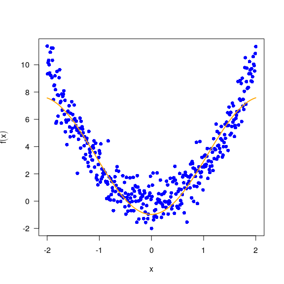

```r
plot(x, y, las=1, col="blue", pch=16, xlab=expression(x), ylab=expression(f(x)))
lines(x, predict(tmp)+mean(y), col="orange", lwd=2)
```

# 2020 July 20

The next step is to turn this stuff into an S3 object interface. Initially, I thought that I wanted to just save the best fit, but now I think I want to save all of the fits that work and the index of the best fit.

The functions that I want to define for this

**predict**

Predicted values for some new data from the best (or a specified) model, or the fitted values from the best (or specified) model.

**plot**

Draw a scatter plot with the data and a fit through it. This is actually too hard to do right now.

**coef**

The coefficients of the best model, or optionally an indexed fit

**formula**

The formula of the best model, or optionally an indexed fit

**summary**

Summarize the best fit, or optionally an indexed fit

**anova**

compare all of the fits in order of degrees of freedom and likelihood

### side note about configuring `lintr`

You can avoid re-creating `my.linters` every time you lint with a `.linter` configuration file in the project directory. It irritates `devtools::check`, though.

## installing on a Windows machine

**MAKE SURE THAT `R` is up to date**

## More checking

I'm going to see if the parameters of the fits actually match the parameters of input functions that are sums of cosines.

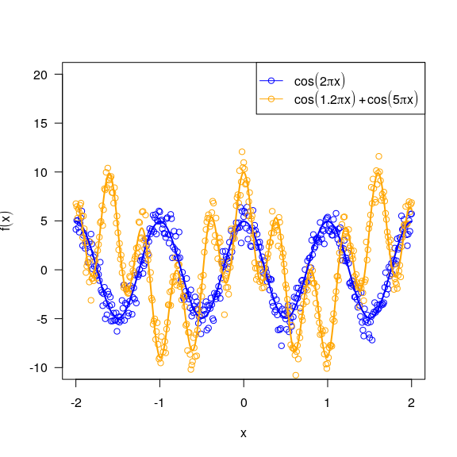

```r
x <- seq(-2, 2, length.out=401)
f <- function(x, a=c(1, 1), b=c(0, 1)){
  a[1]*cos(a[2]*2*pi*x) + b[1]*cos(b[2]*2*pi*x)
}
phi <- c(0.6, 2.5)
y <- 5*f(x) + rnorm(length(x))
yfit <- fffit(x, y)
z <- 5*f(x, c(1, phi[1]), c(1, phi[2])) + rnorm(length(x))
zfit <- fffit(x, z)
plot(x, y,
     las=1,
     ylim=10*c(-1, 2),
     xlab=expression(x), ylab=expression(f(x)),
     pch=1, col="blue")
points(x, z,
      pch=1, col="orange")
lines(x, predict(yfit), col="blue", lwd=2)
lines(x, predict(zfit), col="orange", lwd=2)
legend("topright",
       c(expression(cos(2*pi*x)),
         bquote(cos(.(2*phi[1])*pi*x) + cos(.(2*phi[2])*pi*x))),
       pch=1,
       lty=1,
       col=c("blue", "orange"))
```

```r
summary(yfit)
```

```
#>
#> Formula: y ~ a1 * cos(2 * pi * f1 * x - p1)
#>
#> Parameters:
#>    Estimate Std. Error t value Pr(>|t|)
#> a1 4.945710   0.069794  70.862   <2e-16 ***
#> f1 0.999694   0.001958 510.550   <2e-16 ***
#> p1 0.021230   0.014109   1.505    0.133
#> ---
#> Signif. codes:  0 '***' 0.001 '**' 0.01 '*' 0.05 '.' 0.1 ' ' 1
#>
#> Residual standard error: 0.987 on 398 degrees of freedom
#>
#> Number of iterations to convergence: 6
#> Achieved convergence tolerance: 4.358e-06
```

```r
summary(zfit)
```

```
#>
#> Formula: y ~ a1 * cos(2 * pi * f1 * x - p1) + a2 * cos(2 * pi * f2 * x -
#>     p2)
#>
#> Parameters:
#>     Estimate Std. Error  t value Pr(>|t|)
#> a1  5.020108   0.073632   68.178   <2e-16 ***
#> a2  4.956719   0.074230   66.776   <2e-16 ***
#> f1  0.604357   0.002162  279.561   <2e-16 ***
#> f2  2.502090   0.002116 1182.642   <2e-16 ***
#> p1 -0.009060   0.015064   -0.601    0.548
#> p2 -0.007446   0.015048   -0.495    0.621
#> ---
#> Signif. codes:  0 '***' 0.001 '**' 0.01 '*' 0.05 '.' 0.1 ' ' 1
#>
#> Residual standard error: 1.052 on 395 degrees of freedom
#>
#> Number of iterations to convergence: 7
#> Achieved convergence tolerance: 5.51e-07
```

The fits are pretty amazing, but it's hard to tell what the actual function of x is that it represents! That's something to work on tomorrow, for totes.

# 2020 July 21

## What are the actual parameters that I'm trying to capture?

My previous attempts have involved transforming the original predictor variable into angular frequency in radians. I was calling the linear transformation 'u'. I also assigned a lot of variables as constants, especially the phases.

Noodling around with the results of my first analyses showed that the fits are good, but the coefficients that I found weren't useful. Basically, I was creating fits of the form $y = \sum_i{a_{i} \cos((i-1)u(x) + p_{i}})$, where $u(x) = 2\pi x N_s / K$, where $N_s$ is the sample size, $K$ is the FFT size, and $i$ is the index of a term in the DFT.

What I really want is $y = \sum_i{a_{i} \cos(2 \pi f_i x + p_i)}$. I should have the DFT inform my *inital estimates* for the coefficients, **not** constants.

# 2020 July 22

I made progress yesterday on changing how the results are structured and reported. It's definitely headed toward a more object-oriented approach, and that's going to be much better.

Today I refactored term construction using test-driven development and it was very satisfying and productive. The REPEATED interruptions from the family were easier to deal with because I could pick up at the unit test that wasn't working.

### Weak typing in R

Usually, I prefer to use `NULL` as my marker for "the default behavior didn't happen, but that's OK because there's an anticipated alternative procedure." That did NOT work today when in the `fffterm` constructor. I was trying to convert vectors with `name` attributes to lists with items whose names come from that attribute. R could handle that when the vector contained no `NULL`s, but not when they were present.